# White Wine Exploratory Analysis by Rebecca

This dataset contains information about Portuguese white variants of “Vinho Verde” wine. It includes 4898 observations of 12 features. 11 of the features are chemical variables (independent variables), and the other feature is wine quality (dependent variable), a subjective measure that is the median of the opinions of three wine experts. Specifically, the features are:

- fixed acidity: most acids involved with wine or fixed or nonvolatile (do not evaporate readily)
- volatile acidity: the amount of acetic acid in wine, which at too high of levels can lead to an unpleasant, vinegar taste
- citric acid: found in small quantities, citric acid can add ‘freshness’ and flavor to wines
- residual sugar: the amount of sugar remaining after fermentation stops, it’s rare to find wines with less than 1 gram/liter and wines with greater than 45 grams/liter are considered sweet
- chlorides: the amount of salt in the wine
- free sulfur dioxide: the free form of SO2 exists in equilibrium between molecular SO2 (as a dissolved gas) and bisulfite ion; it prevents microbial growth and the oxidation of wine
- total sulfur dioxide: amount of free and bound forms of S02; in low concentrations, SO2 is mostly undetectable in wine, but at free SO2 concentrations over 50 ppm, SO2 becomes evident in the nose and taste of wine
- density: the density of water is close to that of water depending on the percent alcohol and sugar content
- pH: describes how acidic or basic a wine is on a scale from 0 (very acidic) to 14 (very basic); most wines are between 3-4 on the pH scale
- sulphates: a wine additive which can contribute to sulfur dioxide gas (S02) levels, which acts as an antimicrobial and antioxidant
- alcohol: the percent alcohol content of the wine
- quality: discrete score between 0 (worst) and 10 (best).

(These descriptions have been taken from reference 1.)

```
##  fixed.acidity    volatile.acidity  citric.acid     residual.sugar
##  Min.   : 3.800   Min.   :0.0800   Min.   :0.0000   Min.   : 0.600
##  1st Qu.: 6.300   1st Qu.:0.2100   1st Qu.:0.2700   1st Qu.: 1.700
##  Median : 6.800   Median :0.2600   Median :0.3200   Median : 5.200
##  Mean   : 6.855   Mean   :0.2782   Mean   :0.3342   Mean   : 6.391
##  3rd Qu.: 7.300   3rd Qu.:0.3200   3rd Qu.:0.3900   3rd Qu.: 9.900
##  Max.   :14.200   Max.   :1.1000   Max.   :1.6600   Max.   :65.800
##    chlorides       free.sulfur.dioxide total.sulfur.dioxide
##  Min.   :0.00900   Min.   :  2.00      Min.   :  9.0
##  1st Qu.:0.03600   1st Qu.: 23.00      1st Qu.:108.0
##  Median :0.04300   Median : 34.00      Median :134.0
##  Mean   :0.04577   Mean   : 35.31      Mean   :138.4
##  3rd Qu.:0.05000   3rd Qu.: 46.00      3rd Qu.:167.0
##  Max.   :0.34600   Max.   :289.00      Max.   :440.0
##     density             pH          sulphates         alcohol
##  Min.   :0.9871   Min.   :2.720   Min.   :0.2200   Min.   : 8.00
##  1st Qu.:0.9917   1st Qu.:3.090   1st Qu.:0.4100   1st Qu.: 9.50
##  Median :0.9937   Median :3.180   Median :0.4700   Median :10.40
##  Mean   :0.9940   Mean   :3.188   Mean   :0.4898   Mean   :10.51
##  3rd Qu.:0.9961   3rd Qu.:3.280   3rd Qu.:0.5500   3rd Qu.:11.40
##  Max.   :1.0390   Max.   :3.820   Max.   :1.0800   Max.   :14.20
##     quality
##  Min.   :3.000
##  1st Qu.:5.000
##  Median :6.000
##  Mean   :5.878
##  3rd Qu.:6.000
##  Max.   :9.000
```

# Univariate Plots Section

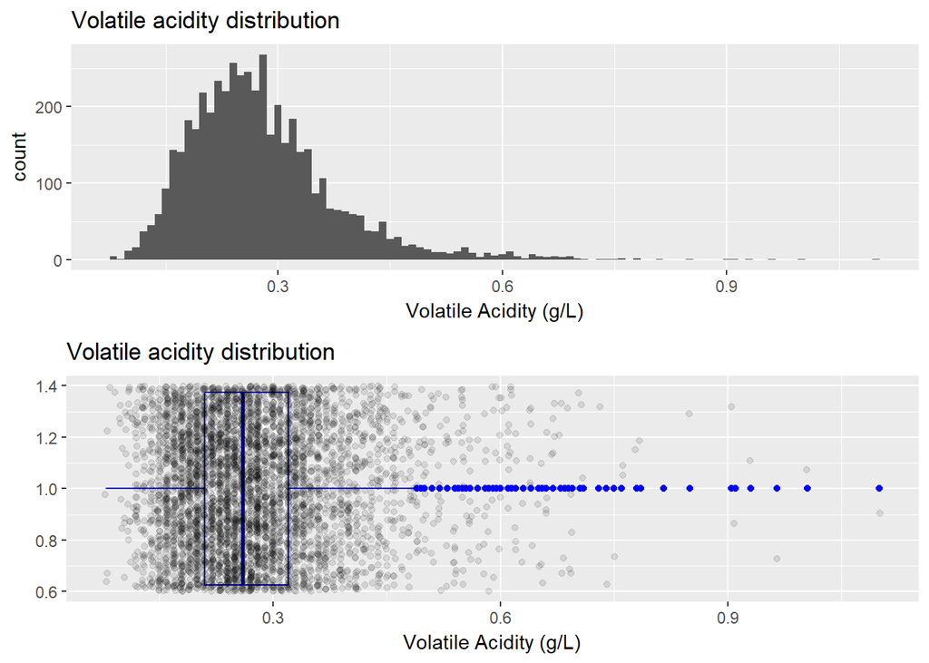

Volatile acidity is right skewed with many outliers above .45 g/L, while the median is .26 g/L, and the minimum value is 0.08 g/L.

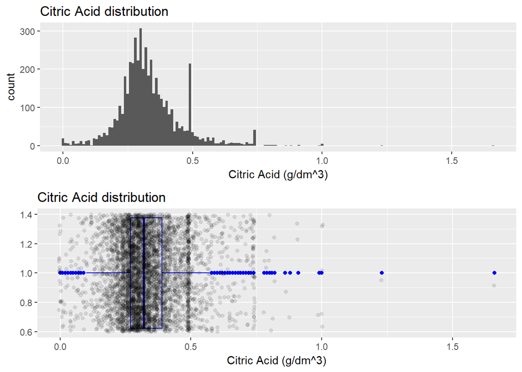

Citric acid is normally distributed, though there is a spike in the histogram 0.5 and 0.75 g/dm^3. Additionally, there are several outliers below the mean, and above the mean.

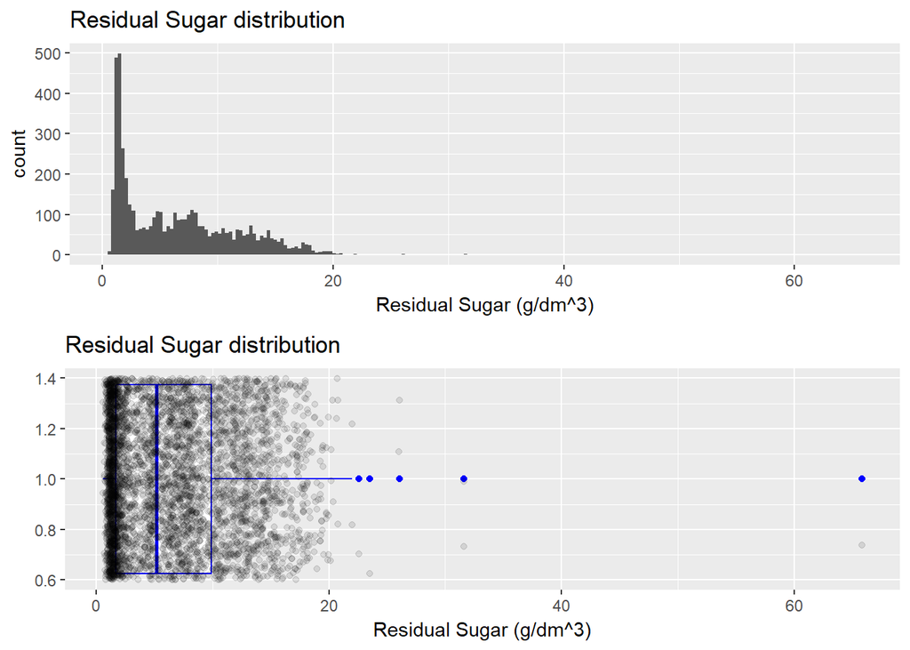

Residual sugar is the most skewed feature, and it is highly right skewed, with most of the data at the first quartile of 1.7 g/dm^3. There are a few outliers above 20 g/dm^3. I will log transform this feature.

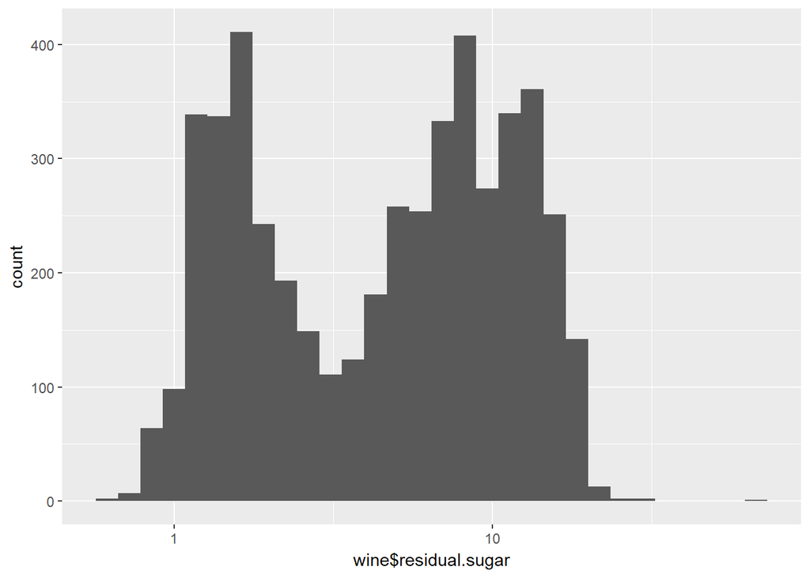

The above histogram shows that a log transform of residual sugar results in a bimodal distribution, with peaks around 2 and 8 g/dm^3.

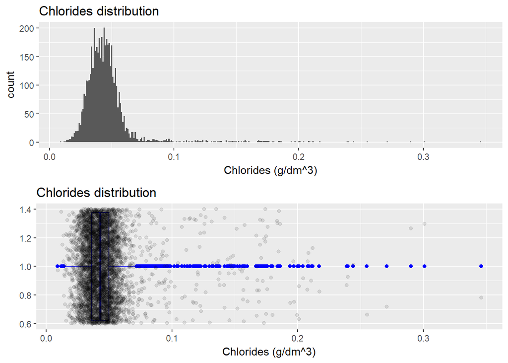

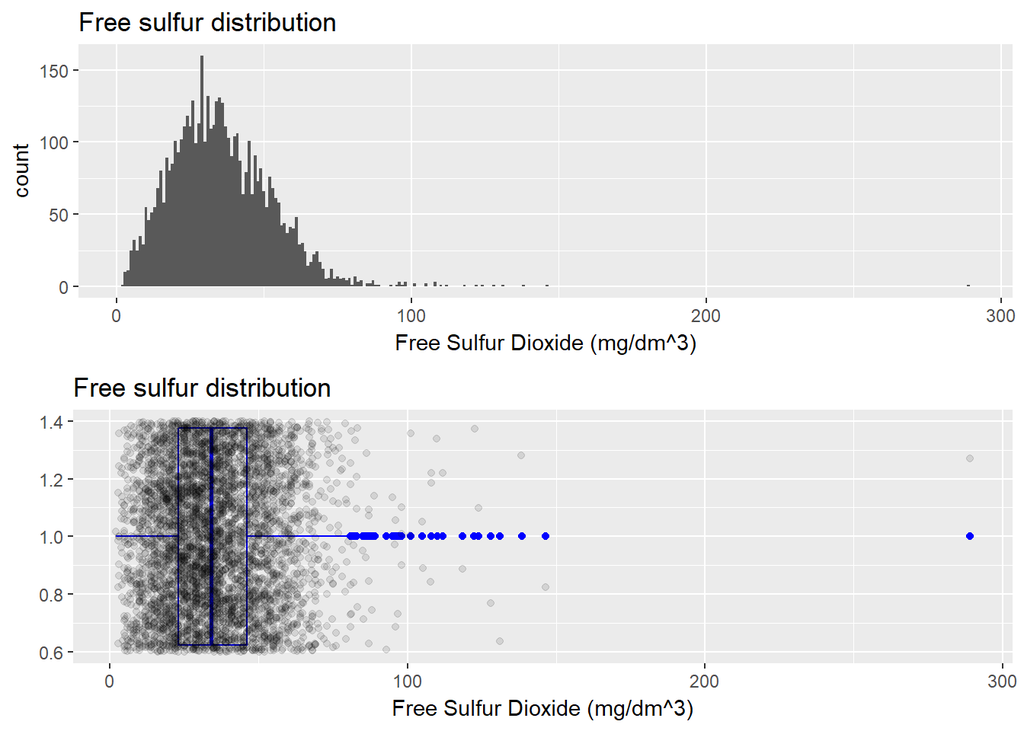

Free sulfur dioxide is normally distributed with a few outliers above about 75 mg/dm^3. The median is 34 mg/dm^3, and the max value is 289 mg/dm^3, so there is clearly a very large range for this feature.

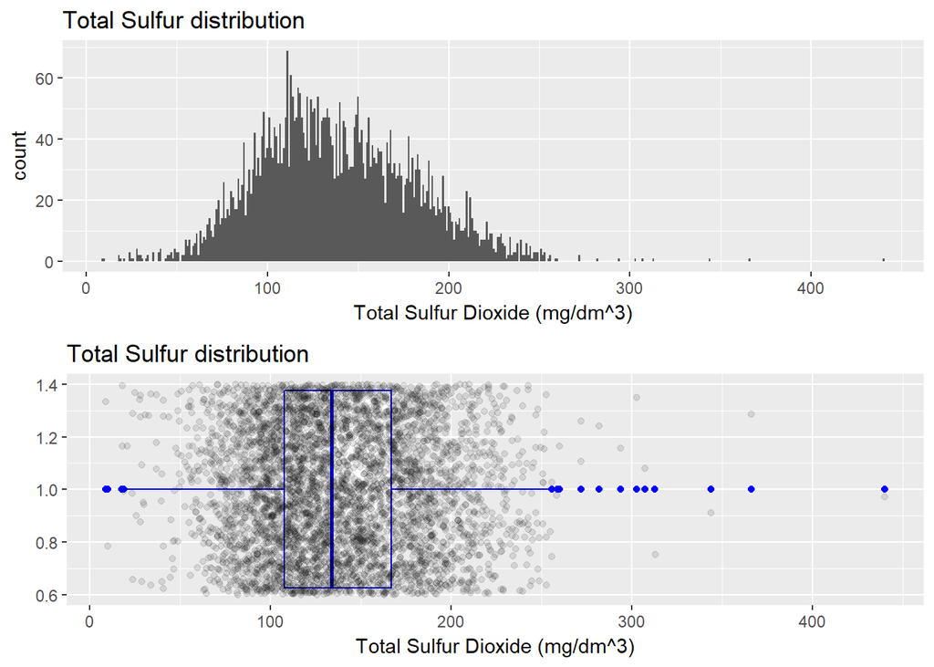

As with free sulfur dioxide, there is a large range for this feature. The mean is 138.4 mg/dm^3, while the max value is 440 mg/dm^3.

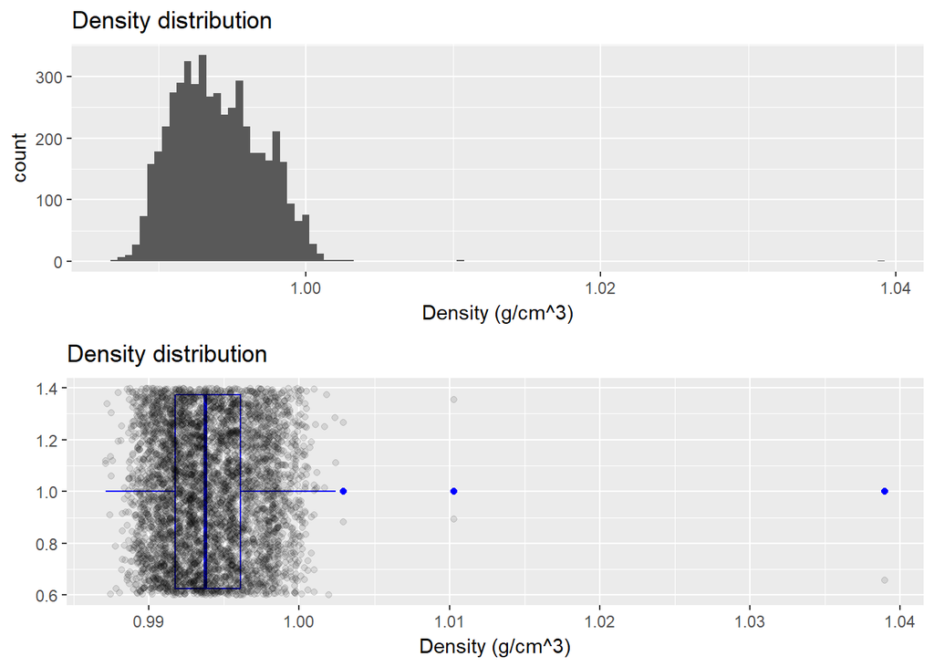

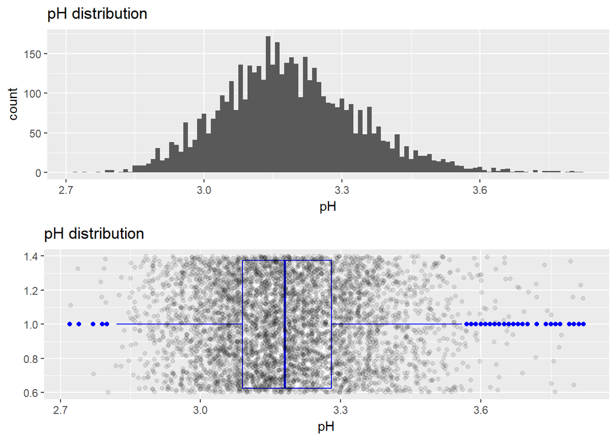

pH is normally distributed with a mean of 3.18, and a few outliers below and above the mean.

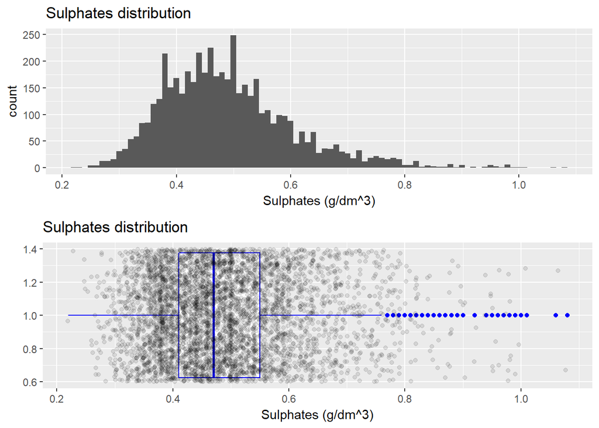

Sulphates is slightly right skewed, with a few outliers above the mean of 0.4898, starting at about 0.8 g/dm^3. The minimum value is 0.22 and the max value is 1.08 g/dm^3.

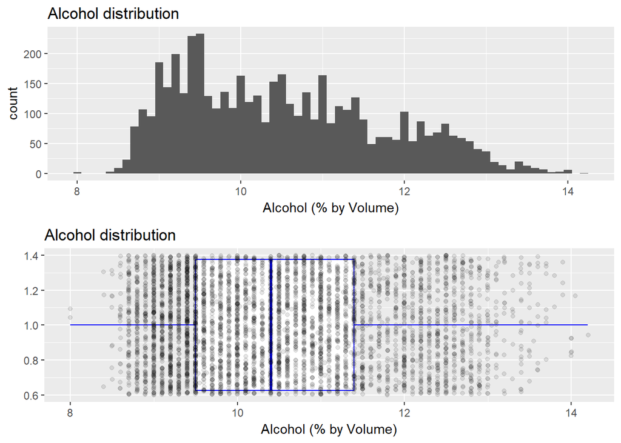

The amount of alcohol by volume in a wine is a flat distribution, with a range of 8 to 14 % by volume.

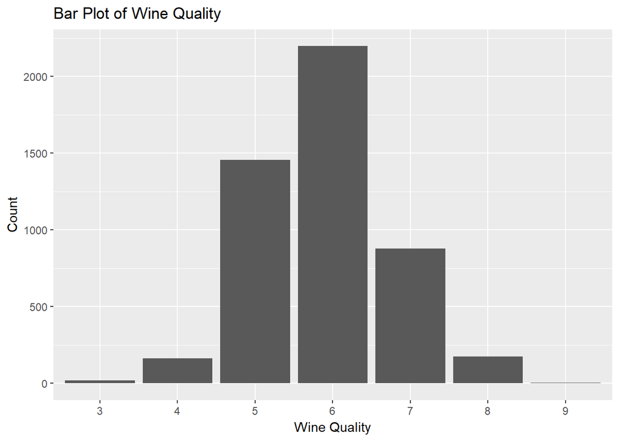

The above histogram shows that most of the wines in the dataset are good, with a quality between 5 and 7. Most of the wines have a quality of 6.

# Univariate Analysis

### What is the structure of your dataset?

The dataset contains 4898 observations of 12 features. All of the features are numeric, and quality is a discrete variable that takes on the integers from 0 to 10.

### What is/are the main feature(s) of interest in your dataset?

The main feature of interest is quality, as that is the feature that can be predicted from the others.

### What other features in the dataset do you think will help support your investigation into your feature(s) of interest?

I think that residual sugar, volatile acidity, and alcohol will help support my investigation into my feature of interest, as the first two features have skewed distributions, and alcohol has a relatively flat (large spread) distribution.

### Did you create any new variables from existing variables in the dataset?

No.

### Of the features you investigated, were there any unusual distributions? Did you perform any operations on the data to tidy, adjust, or change the form of the data? If so, why did you do this?

I log-transformed the feature residual sugar since it was a feature that was highly right skewed.

# Bivariate Plots Section

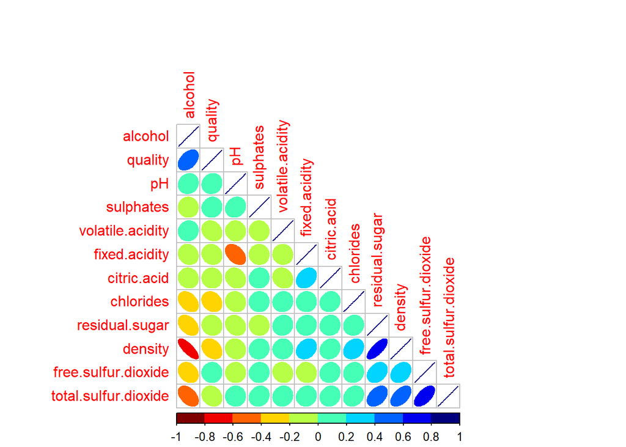

The correlation plot shows that strong correlations exist between sulfur dioxide and free sulfur dioxide, alcohol and density, density and residual sugar, and alcohol and quality.

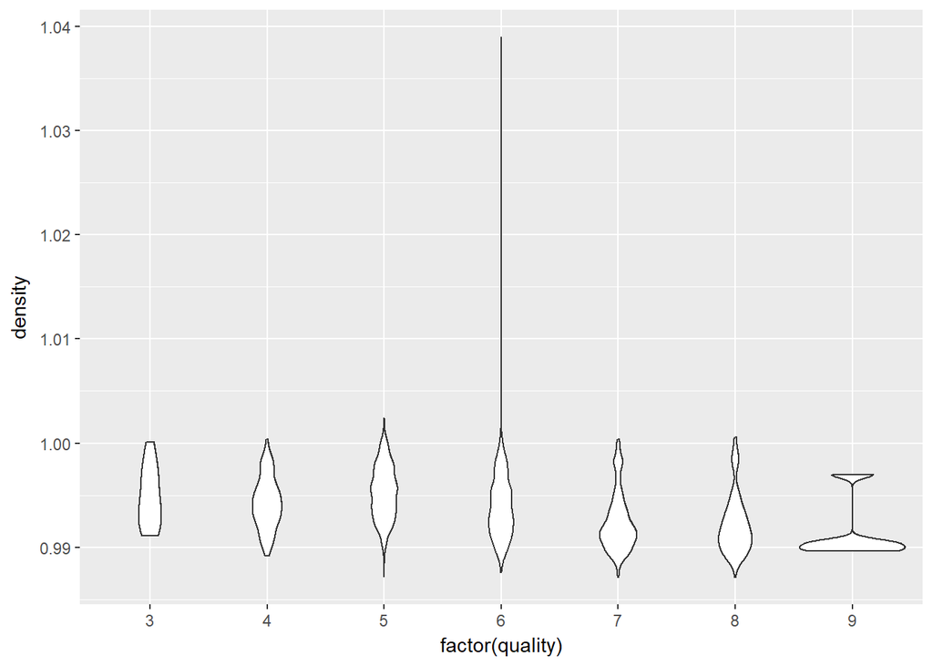

The above violin plot shows that in general, better wines have lower densities, with a few outliers that have a quality of 6. This relationship is strongest for wines rated to have the highest quality in the dataset (9), where nearly all of the wines with a rating of 9 have a density of about 0.99. The range in density for the other quality ratings has a larger spread.

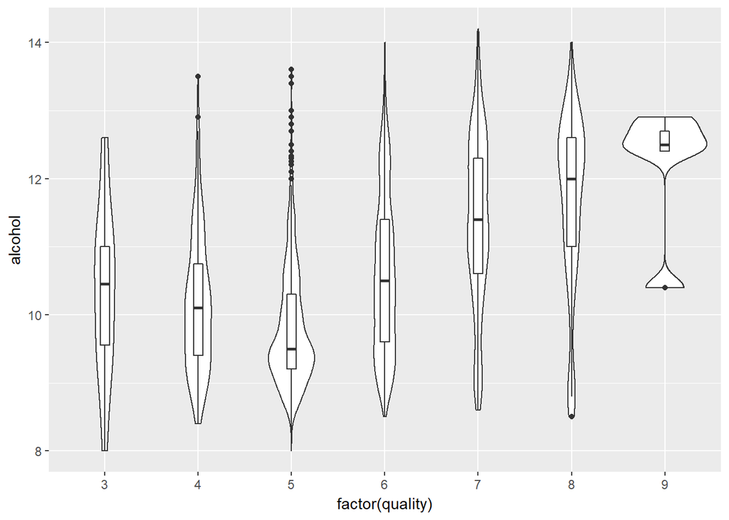

The above violin plot shows that in general, better wines have higher alcohol content. As with density, this relationship is strongest for wines with a quality rating of 9, where most of the 9s have an alcohol by volume percentage above 12. The range in alcohol for the other quality ratings has a larger spread.

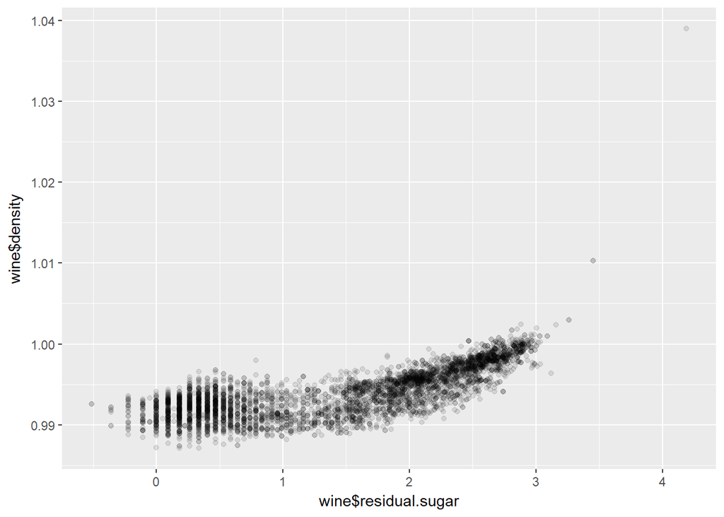

# Bivariate Analysis

### Talk about some of the relationships you observed in this part of the investigation. How did the feature(s) of interest vary with other features in the dataset?

From the correlation plot, we see that free sulfur dioxide and total sulfur dioxide are positively correlated with each other, which makes sense since free sulfur dioxide is a component of total sulfur dioxide.

From the correlation plot and the violin plots, we see that alcohol and density are negatively correlated. Additionally, we see that residual sugar and density are positively correlated. The correlation plot shows that volatile acidity doesn’t have any strong correlations between any of the other features.

### Did you observe any interesting relationships between the other features (not the main feature(s) of interest)?

Fixed acidity has a moderate negative correlation with pH, while volatile acidity does not have a strong relationship with pH.

### What was the strongest relationship you found?

The strongest positive relationship that I found was between density and residual sugar. The strongest negative relationship was between alcohol and density.

# Multivariate Plots Section

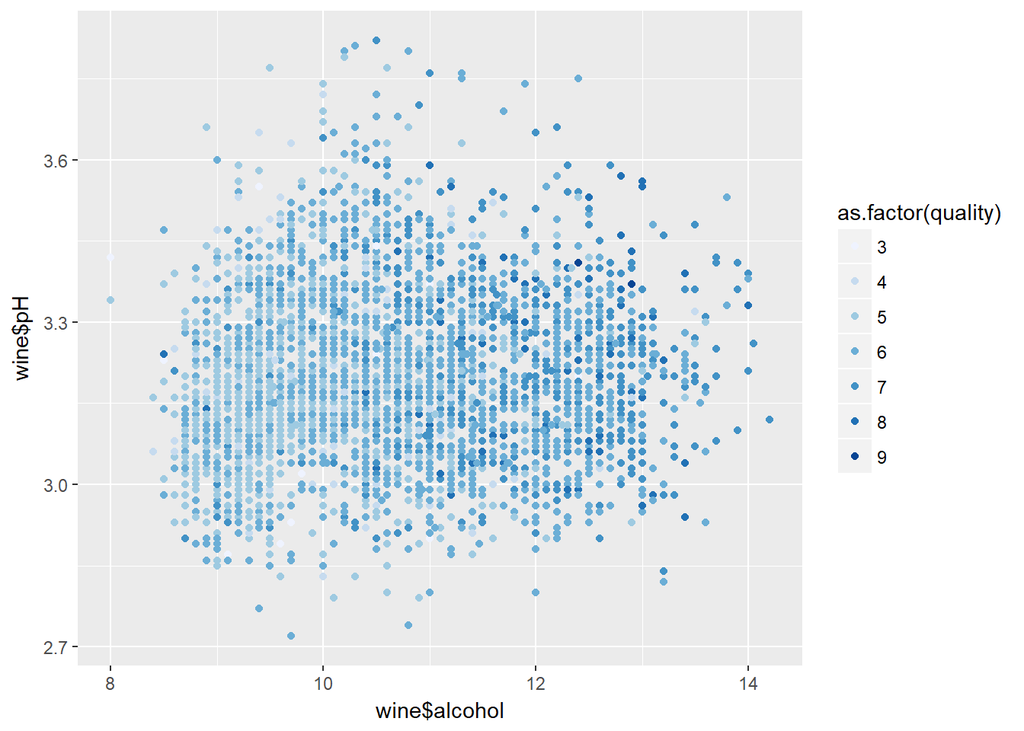

The scatter plot between pH and alcohol shows a basically flat distribution, with better wines having higher alcohol contents, and a spread in pH.

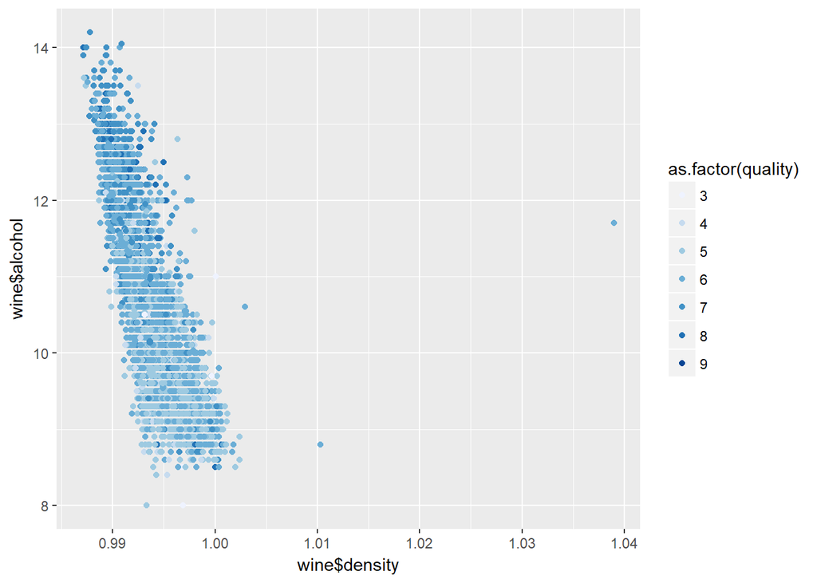

The scatter plot between density and alcohol shows a negative relationship between density and alcohol. Better wines have lower densities and higher alcohol content. There is one outlier (probably the same one as below).

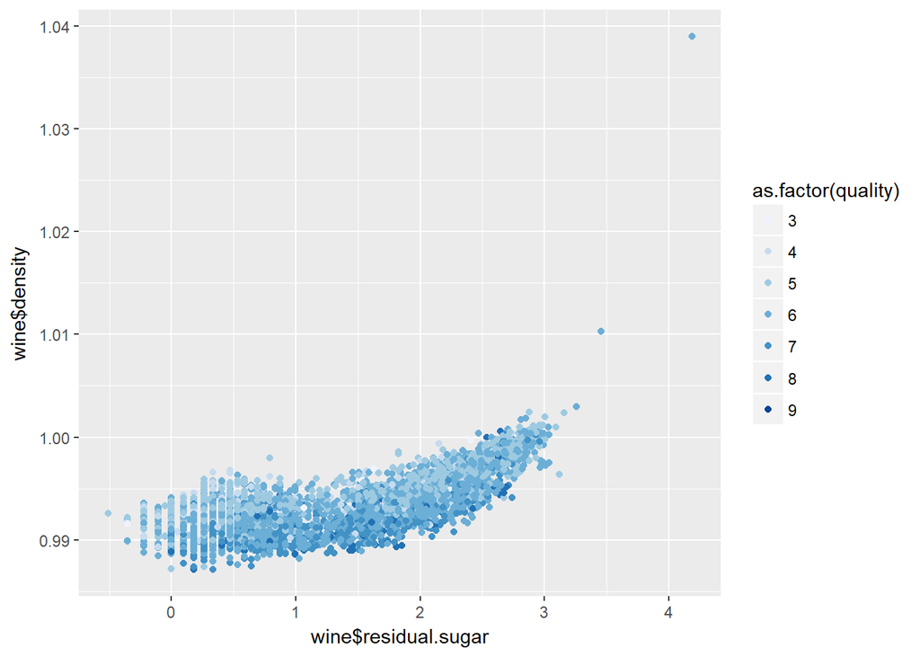

# Multivariate Analysis

### Were there any interesting or surprising interactions between features?

I found it interesting that sugar and density are positively correlated, since I would not expect that these two features were related.

### OPTIONAL: Did you create any models with your dataset? Discuss the strengths and limitations of your model.

# Final Plots and Summary

### Plot One

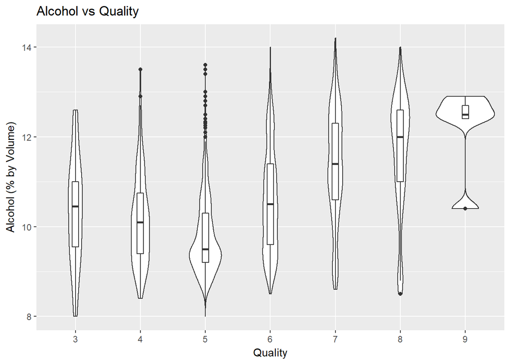

### Plot Two

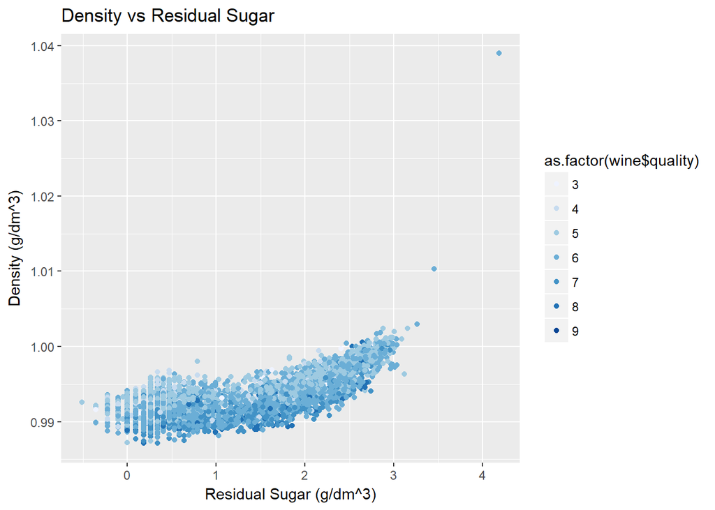

### Plot Three

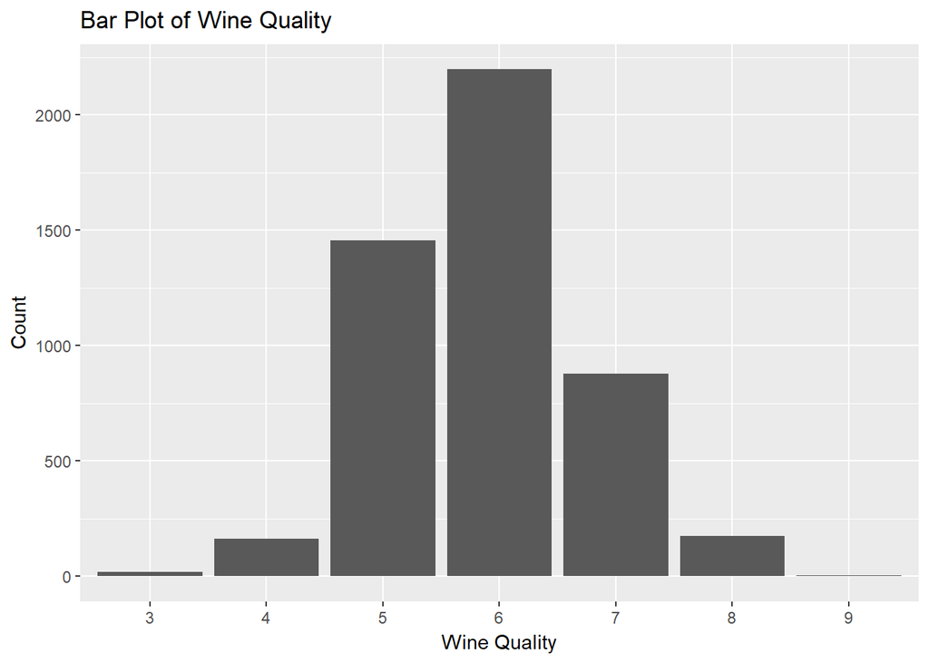

### Description Three

Most of the wines in the dataset have a quality of 6. Furthermore, the quality is normally distributed, with most of wines having a rating between 5 and 7.

# Reflection

From this exploratory analysis, we see that good wine tends to have more alcohol and lower density. Since density increases with an increase of sugar, sugar might be bad for the flavor of wine, while alcohol is good for the flavor of wine. This analysis is based on correlation, so it does not imply any causation between the variables.

Limitations of the analysis are that the dataset is for wines from a particular region, so the relationship between the variables might not hold for different types of wine. Additionally, the quality for the wines might be judged differently by different experts. To study the data further, we could look at doing a controlled experiment, or using machine learning to create predictive models based on this dataset.

References: https://s3.amazonaws.com/udacity-hosted-downloads/ud651/wineQualityInfo.txt